# Project 2 -Data Tidying. Code Base.

Author

Maxim Arisov

Published

October 11, 2026

## **Project 2. Data Transformations.**

## **Approach.**

First, I will collect the three distinct wide-format datasets from the Week 5 Discussion items, create a GitHub repository, and upload them there.

One of the datasets will be mine: the Electric Vehicle Population Size History dataset from Washington state. First, I will download the CSV file and check the data. Then I will look at the columns and missing values. Next, I will use R with tidyr and dplyr to clean the data. I will also use pivot_longer() to change the data from wide format to long format.

Then, I will compare Plug-in Hybrid Electric Vehicles (PHEVs) and Battery Electric Vehicles (BEVs). Then, I will use tables and graphs to show how the number of electric vehicles has changed over time.

Overall, I will explain what I found and write a conclusion. I will upload my work to GitHub.

For another dataset, I will be using the Military Expenditure dataset from SIPRI – sheet “Constant (2024) US$. I will use the same approach as I mentioned above (downloading the CSV file to R, using dplyr and tidyr to clean data, handling missing values, changing to long format, etc.). I will compare the military spending of countries, Russia, China, and the United States over time. The graphs will be presented to demonstrate how the spending has changed. Finally, I will explain the results and write a conclusion about differences in military spending of China, the USA, and Russia.

The third dataset I will be using is New York Housing Borough, applying the same strategy as for the previous two datasets. I will compare the prices of the housing across the five boroughs. A conclusion will be provided at the end, and work will be uploaded ot GitHub.

GitHub links of raw data:

https://raw.githubusercontent.com/Maximus2485/Project-2.-Data-Tidying./refs/heads/main/export.csv

https://raw.githubusercontent.com/Maximus2485/Project-2.-Data-Tidying./refs/heads/main/SIPRI-Milex-data-1949-2025_v1.2.csv

https://raw.githubusercontent.com/Maximus2485/Project-2.-Data-Tidying./refs/heads/main/Project%202%20-%20New%20York%20Housing%20Boroughs.csv

## **Code Base**

```r
#Lets upload required packages to use for all three datasets
library(tidyverse)
library(dplyr)
library(tidyr)
```

### **Electric Vehicle Population dataset.**

### **3.1 Raw data construction.**

```r
# The dataset was created as CSV file and uploaded into GitHub repository. Lets download the CSV file as raw data from GitHub repository and check the first dataset.

electric_vehicle_population_raw <- read.csv("https://raw.githubusercontent.com/Maximus2485/Project-2.-Data-Tidying./refs/heads/main/export.csv")
head(electric_vehicle_population_raw)
```

```
               Date Plug.In.Hybrid.Electric.Vehicle..PHEV..Count
1  January 31, 2017                                        7,686
2 February 28, 2017                                        7,887
3    March 31, 2017                                        8,091
4    April 30, 2017                                        8,285
5      May 31, 2017                                        8,495
6     June 30, 2017                                        8,749
  Battery.Electric.Vehicle..BEV..Count Electric.Vehicle..EV..Total
1                               14,738                      22,424
2                               15,206                      23,093
3                               15,596                      23,687
4                               16,105                      24,390
5                               16,570                      25,065
6                               16,988                      25,737
```

```r
view(electric_vehicle_population_raw)
```

### **3.2 Data import and tidying**

```r
# Lets rename the columns for easier work with dataset
  electric_vehicle_population_raw <- electric_vehicle_population_raw %>%
    rename(phev_count = Plug.In.Hybrid.Electric.Vehicle..PHEV..Count,
           bev_count = Battery.Electric.Vehicle..BEV..Count,
           ev_total = Electric.Vehicle..EV..Total
      )
  view(electric_vehicle_population_raw)
```

```r
# Lets check whether this dataset has any missing values with a help of dplyr
electric_vehicle_population_raw %>%
  summarize(across(c(phev_count,bev_count, ev_total, Date), ~ sum(is.na(.))))
```

```
  phev_count bev_count ev_total Date
1          0         0        0    0
```

```r
# Lets reshape the data from wide to long by combining vehicles into one category column.
electric_vehicle_long <- electric_vehicle_population_raw %>%
  pivot_longer(
    cols = c(phev_count, bev_count),
    names_to = "type_of_vehicle",
    values_to = "count"
  )
head(electric_vehicle_long)
```

```
# A tibble: 6 × 4
  Date              ev_total type_of_vehicle count
  <chr>             <chr>    <chr>           <chr>
1 January 31, 2017  22,424   phev_count      7,686
2 January 31, 2017  22,424   bev_count       14,738
3 February 28, 2017 23,093   phev_count      7,887
4 February 28, 2017 23,093   bev_count       15,206
5 March 31, 2017    23,687   phev_count      8,091
6 March 31, 2017    23,687   bev_count       15,596
```

```r
#Lets convert date to date format and count to numeric
electric_vehicle_long <- electric_vehicle_long |>   # LLM was used to remove comma characters in count and ev total columns and create the date to date format
  mutate(
    Date = as.Date(Date, format = "%B %d, %Y"),
    count =as.numeric(gsub(",", "", count)),
    ev_total = as.numeric(gsub(",", "", ev_total))
  )
head(electric_vehicle_long)
```

```
# A tibble: 6 × 4
  Date       ev_total type_of_vehicle count
  <date>        <dbl> <chr>           <dbl>
1 2017-01-31    22424 phev_count       7686
2 2017-01-31    22424 bev_count       14738
3 2017-02-28    23093 phev_count       7887
4 2017-02-28    23093 bev_count       15206
5 2017-03-31    23687 phev_count       8091
6 2017-03-31    23687 bev_count       15596
```

```r
#Lets compare vehicle types
electric_vehicle_summary <- electric_vehicle_long |>
  group_by(type_of_vehicle) |>
  summarize(
    Average_Count = mean(count, na.rm =TRUE),
    .groups ="drop"
  )
electric_vehicle_summary
```

```
# A tibble: 2 × 2
  type_of_vehicle Average_Count
  <chr>                   <dbl>
1 bev_count              91543.
2 phev_count             28079.
```

### **3.3 Analysis of electric vehicle population dataset**

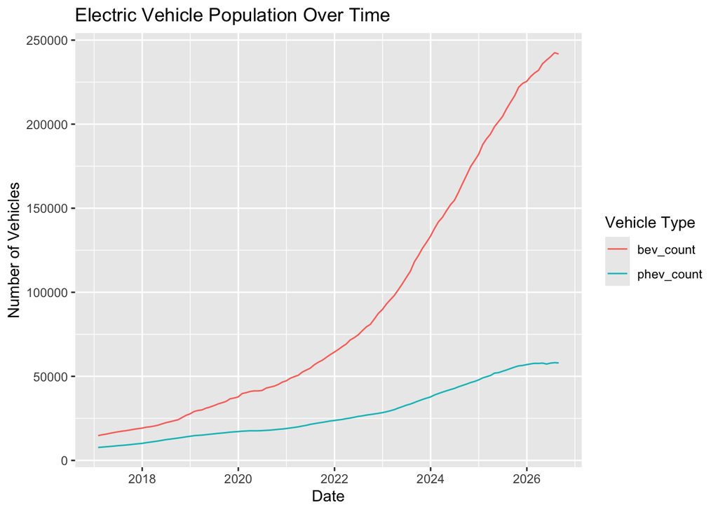

```r
# Lets create the graph with ggplot and show changes occuring over time

ggplot(electric_vehicle_long,
  aes(x = Date, y= count, color =type_of_vehicle, group = type_of_vehicle)) +
  geom_line() +
  labs(
    title ="Electric Vehicle Population Over Time",
    x = "Date",
    y = "Number of Vehicles",
    color = "Vehicle Type"
  )
```

### **Conclusion**

The graph shows that the number of Electric vehicles in Washington State has increased over time. Moreover, both types of vehicles, BEV and PHEV, have increased in number since 2017. However, we can see from the graph that BEVs increased dramatically by 2026, totaling 240,000 cars, compared to PHEVs with a total of approximately 58,000 cars. Thus, battery electric vehicles are more popular and have been more common in Washington State.

### New York Housing Boroughs dataset.

### 3.1 Raw data construction

```r
#The dataset was created as CSV file and uploaded into GitHub repository. Lets import original data as CSV file in raw format from GitHub repository
housing_raw <- read.csv("https://raw.githubusercontent.com/Maximus2485/Project-2.-Data-Tidying./refs/heads/main/Project%202%20-%20New%20York%20Housing%20Boroughs.csv")
view(housing_raw)

#Lets check original data
dim(housing_raw)
```

```
[1] 120   7
```

```r
head(housing_raw)
```

```
  Year Month Bronx Brooklyn Manhattan Queens Staten.Island
1 2024   Jan   565      948     1,108    650           675
2 2024   Feb   568      952     1,112    654           678
3 2024   Mar   572      958     1,118    660           683
4 2024   Apr   575      965     1,122    663           688
5 2024   May   579      972     1,128    668           693
6 2024   Jun   582      978     1,132    671           697
```

```r
names(housing_raw)
```

```
[1] "Year"          "Month"         "Bronx"         "Brooklyn"
[5] "Manhattan"     "Queens"        "Staten.Island"
```

### **3.2 Data import and tidying**

```r
#Lets change Year to an integer, put months in the correct order, remove commas from values with gsub, change the borough values to numbers.
housing_raw <- housing_raw |>
  mutate(
    Year = as.integer(Year),
    Month = factor(Month, levels = month.abb, ordered =TRUE),
    across(Bronx:Staten.Island,
           ~as.numeric(gsub(",", "", .)))
    )
head(housing_raw)
```

```
  Year Month Bronx Brooklyn Manhattan Queens Staten.Island
1 2024   Jan   565      948      1108    650           675
2 2024   Feb   568      952      1112    654           678
3 2024   Mar   572      958      1118    660           683
4 2024   Apr   575      965      1122    663           688
5 2024   May   579      972      1128    668           693
6 2024   Jun   582      978      1132    671           697
```

```r
#Lets change from wide to long format using tidyr function
housing_long <- housing_raw |>
  pivot_longer(
    cols =c(Bronx,Brooklyn, Manhattan, Queens, Staten.Island),
    names_to = "Borough",
    values_to = "Value"
  )
view(housing_long)
```

```r
#Lets check our dataset for missing values. LLM was used to help to find in alternative and simple way
colSums(is.na(housing_long))
```

```
   Year   Month Borough   Value
      0       0       0     384
```

```r
#Lets calculate average by borough,but the missing values will be ignored (na.rm=TRUE)
housing_summary <- housing_long |>
  group_by(Borough) |>
  summarize(
    Average_Value = mean(Value, na.rm =TRUE),
    .groups ="drop"
  )
housing_summary
```

```
# A tibble: 5 × 2
  Borough       Average_Value
  <chr>                 <dbl>
1 Bronx                  595.
2 Brooklyn               869.
3 Manhattan             1153.
4 Queens                 687.
5 Staten.Island          714.
```

### **3.3 Analysis of dataset**

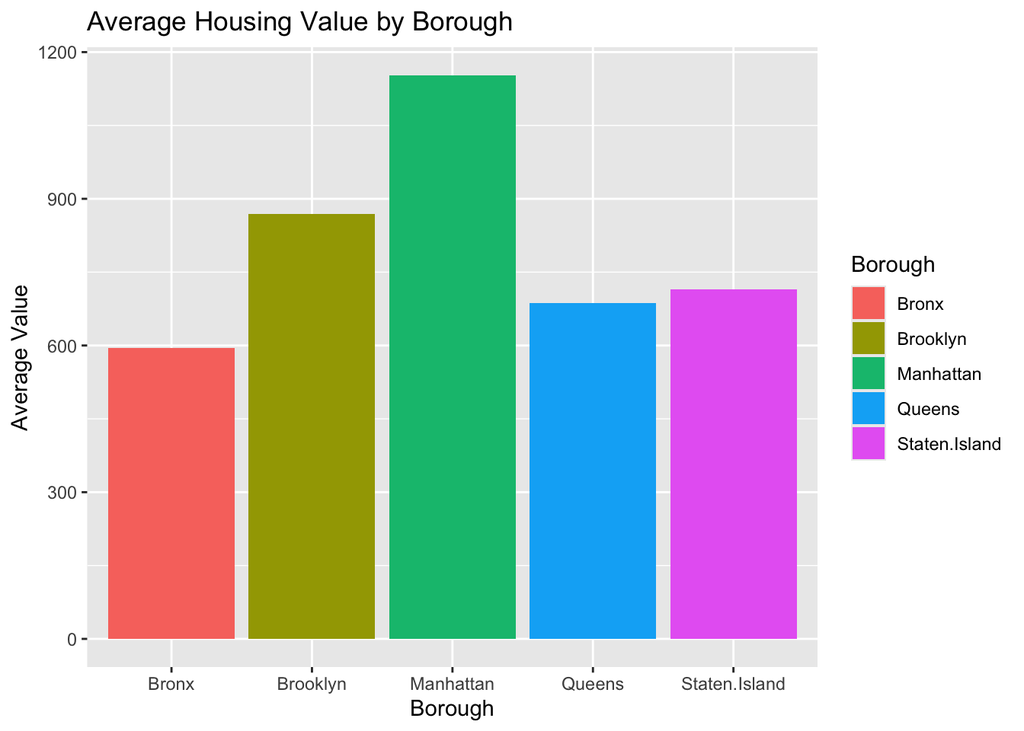

```r
# Lets create graph to see average housing value by Borough
ggplot(housing_summary,
       aes(x= Borough, y = Average_Value, fill= Borough))+
  geom_col()+
  labs(
    title = "Average Housing Value by Borough",
    x="Borough",
    y="Average Value"
  )
```

### **Conclusion**

Overall, Manhattan has the highest housing values than other 4 borough, and Bronx has the lowest. Thus, it shows that housing values vary among the boroughs.

### **Military Expenditure dataset**

### **3.1 Raw Data construction**

```r
# The dataset was created as CSV file and uploaded into GitHub repository.
# Lets import raw data and remove unnessary first 4 rows, keep original column headers as they are, and assign cells containing empty space, triple dots, etc. as missing values.
military_expenditure_raw <- read.csv("https://raw.githubusercontent.com/Maximus2485/Project-2.-Data-Tidying./refs/heads/main/SIPRI-Milex-data-1949-2025_v1.2.csv",
                                     skip = 4,
                                     check.names = FALSE,
                                     na.strings = c("","...", "xxx")
)
view(military_expenditure_raw)
head(military_expenditure_raw)
```

[output not shown]

[output cut: 33 more lines]

### **3.2 Import and Tidying of dataset.**

```r
#Lets use the first row as column names
names(military_expenditure_raw) <- as.character(military_expenditure_raw[1,])
#Lets remove the first row
military_expenditure_raw <- military_expenditure_raw[-1,]
view(military_expenditure_raw)
```

```r
#Lets remove extra columns NA
military_expenditure_clean <- military_expenditure_raw |>
  select(Country, matches("^[0-9]{4}$")) # A pattern matching rule to find strings that consist of exaclty four numeric digits was used with LLM.
view(military_expenditure_clean)
```

```r
#Lets select three countries "Russia", "China", and "United States of America" start from year 1992 and change to long format.
military_expenditure_long <- military_expenditure_clean |>
  filter(Country %in% c("China", "Russia", "United States of America"))|>
  pivot_longer(
    cols = -Country,
    names_to = "Year",
    values_to = "Expenditure",
    values_transform = list(Expenditure =as.character)
  )|>
  mutate(
    Year =as.integer(Year),
    Expenditure=as.numeric(gsub(",", "", Expenditure))
  )|>
  filter(Year >= 1992)
view(military_expenditure_long)
```

```r
#Lets calculate average spending of the three countries
military_expenditure_summary <- military_expenditure_long |>
  group_by(Country)|>
  summarize(
    Average_Spending = mean(Expenditure, na.rm = TRUE),
    .groups ="drop"
  )
military_expenditure_summary
```

```
# A tibble: 3 × 2
  Country                  Average_Spending
  <chr>                               <dbl>
1 China                             135412.
2 Russia                             55328.
3 United States of America          816477.
```

### **3.3 Analysis of dataset.**

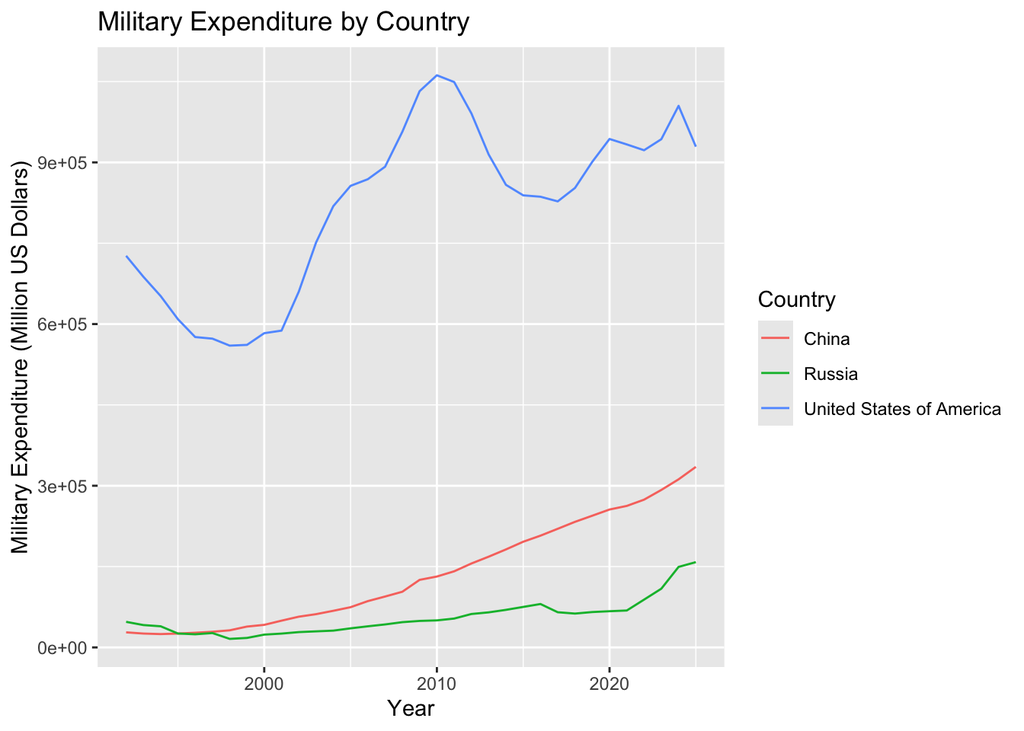

```r
#Lets create the graph to see military expenditure by country
ggplot(military_expenditure_long, aes(x=Year, y=Expenditure, color= Country)) +
  geom_line() +
  labs(
    title = "Military Expenditure by Country",
    x = "Year",
    y = "Military Expenditure (Million US Dollars)",
    color = "Country"
  )
```

### **Conclusion**

Overall, the United States has been spending the most on its military, while Russia showed a sharp increase starting from 2020, and China revealed a steady growth.

### References

Google Deep Mind. (2026). Gemini 3 Flash [Large language model]. [https://gemini.google.com.%5D(https://gemini.google.com/) Accessed October11th, 2026.

Wickham, H., Çetinkaya-Rundel, M., & Grolemund, G. (2023). *R for data science* (2nd ed.). O’Reilly Media. https://r4ds.hadley.nz/